# Introduction to the pifpaf package: Estimating Potential Impact and Population Attributable Fractions from Cross-Sectional data

### Hessian might not be defined

Error message: `Hessian might not be defined for those values of rr` states that it was impossible to numerically estimate the Hessian for the approximate expected value of the Relative Risk. There are two main reasons for this: 1) values of the `rr` are extremely large or 2) the relative risk function is not differentiable.

```r
#Extremely large values of rr
pif(as.data.frame(2.61573e+22), 1, rr = function(X, theta){exp(theta*X)}, cft = function(X){X/2},
    Xvar = 100, method = "approximate")
```

```
## Error in pif.approximate(X = X, Xvar = Xvar, thetahat = thetahat, rr = rr, : Hessian might not be defined for those values of rr
```

```r
#rr not differentiable at 0
rr <- function(X, theta){
  sqrt(X)
}
paf(as.data.frame(0), 1, rr = rr, method = "approximate", Xvar = 1, check_rr = FALSE)
```

```
## Warning in sqrt(X): NaNs produced

## Warning in sqrt(X): NaNs produced

## Warning in sqrt(X): NaNs produced

## Warning in sqrt(X): NaNs produced
```

```
## Error in pif.approximate(X = X, Xvar = Xvar, thetahat = thetahat, rr = rr, : Hessian might not be defined for those values of rr
```

### Under this density some values are NA

Warning message `Under this kernel density some values of cft are NA` and `Under this kernel density some values of rr are NA` indicate that the adjusted density is in a domain where the `rr` or the `cft` are not defined. For example consider the following `rr` and `X`:

```r
X  <- rlnorm(100)
rr <- function(X, theta){sqrt(X) + 1}
```

By construction, all values of `X` are positive; however, the `"gaussian"` kernel density adjusts the density to include some negative values:

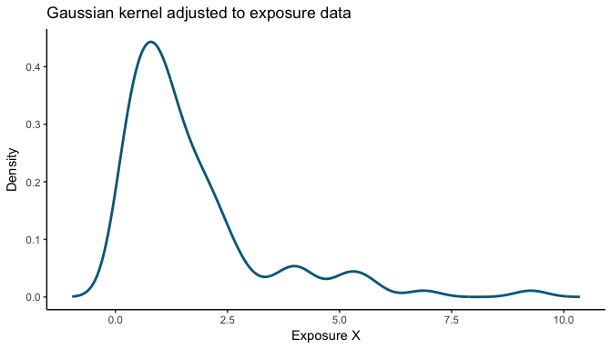

```r
paf(as.data.frame(X), 0.12, rr = rr, method = "kernel", ktype = "gaussian")
```

```
## [1] 0.5281559
```

There are two ways of fixing this: using the empirical method or changing the Relative Risk function:

```r
#Using empirical method
paf(data.frame(X), 0.12, rr = rr, method = "empirical")
```

```
## [1] 0.5395949
```

```r
#Rewriting RR function
rr <- function(X, theta){
  Xnew            <- as.data.frame(rep(0, nrow(X)))
  Xnew[which(X[,1] >= 0),1] <- sqrt(X[which(X[,1] >= 0),1] ) + 1
  return(Xnew)
}
paf(data.frame(X), 0.12, rr = rr, method = "kernel", ktype = "gaussian")
```

```
## [1] 0.5286501
```

```r
pif.kernel(as.data.frame(X), 0.12, rr)
```

```
## [1] 0.5286501
```

## References

1. Murray CJ, Ezzati M, Lopez AD, et al. Comparative quantification of health risks: Conceptual framework and methodological issues. *Population health metrics*. 2003;1(1):1.

2. Vander Hoorn S, Ezzati M, Rodgers A, et al. Estimating attributable burden of disease from exposure and hazard data. *Comparative quantification of health risks: global and regional burden of disease attributable to selected major risk factors. Geneva: World Health Organization*. 2004;2129–40.

3. Barendregt JJ, Veerman JL. Categorical versus continuous risk factors and the calculation of potential impact fractions. *Journal of epidemiology and community health*. 2010;64(3):209–212.

4. Lawes CM, Vander Hoorn S, Law MR, et al. Blood pressure and the global burden of disease 2000. part 1: Estimates of blood pressure levels. *Journal of hypertension*. 2006;24(3):413–422.

5. Wasserman L. All of nonparametric statistics. Springer; 2006.

6. Casella G, Berger RL. Statistical inference. Duxbury Pacific Grove, CA; 2002.

7. Bar-Lev SK, Reiser B. On confidence intervals for nonmonotone parametric functions and an application to the squared mean of the normal distribution. *Statistical Papers*. 1999;40(1):89–98.